# g95summary

## G95 Summary Lac Léman

### Incidence of cotton swabs by location and significant values

#### Definition of significant values

#### National results:

#### Lac Léman G95 utilisation and availability

questions or comments: analyst@hammerdirt.ch

### Methods

#### **Data source, time frame, geographic scope and collection methods**

All surveys that were conducted on Bielersee, Neuenburgersee, Thunersee, Walensee, Zurichsee, Lac Léman, Brienzersee and Lago Magiore were considered.

The data was collected according to the protocol described here https://www.plagespropres.ch/. In brief all visible data is collected along a beach within a measured distance from the waters edge. The width of the survey area depends on the terrain and the water level. The visible strand line or the nearest physical structure defines the width of a survey.

Surveys were conducted by the following organizations:

1. hammerdirt
2. Association pour le Sauvegarde du leman
3. Solid Waste Management Ecole Polytechnique Federal
4. Ecole International de Geneve
5. Precious plastic leman
6. Why isn't your association here?

This analysis is an open source document. The working note book is available in the repository located here https://github.com/hammerdirt-analyst/iqals.

**Francais**

Toutes les enquêtes qui ont été menées sur le lac de Bienne, le lac de Neuchâtel, le lac de Thoune, le lac Walensee, le lac de Zurich, le lac Léman, le lac Brienzer et le lac Magiore ont été prises en compte.

Les données ont été collectées selon le protocole décrit ici [https://www.plagespropres.ch/] (https://www.plagespropres.ch/). En bref, toutes les données visibles sont collectées le long d'une plage à une distance mesurée du bord de l'eau. La largeur de la zone d'étude dépend du terrain et du niveau de l'eau. La ligne de rive visible ou la structure physique la plus proche définit la largeur d'une enquête.

Des enquêtes ont été menées par:

Cette analyse est un document open source. Le cahier de notes de travail est disponible dans le dépôt situé ici: https://github.com/hammerdirt-analyst/iqals.

#### Scope of surveys

The scope of the surveys includes the total population levels and land use configuration for the adjacent municipality. Land use is quantified by calculating the m² of space attributed to buildings wtihin 500m of the survey location and the total length in meters of roads within 1000m of the survey location*.

The results and survey locations can be classified according to the following attributes:

1. M² of buildings within 500m of the survey
2. Total length of streets/roads within 1000m of the survey
3. Number of river/canal intersections within 1500m of the survey
4. Population of the surounding municipality

*Values are calculated using https://shop.swisstopo.admin.ch/en/products/landscape/tlm3D

**Français**

Le champ d'application des enquêtes comprend les niveaux de population totale et la configuration de l'utilisation des sols pour la municipalité environante. L'utilisation des sols est quantifiée en calculant la superficie en m² attribuée aux bâtiments dans un rayon de 500 m du lieu de l'enquête et la longueur totale en mètres des routes dans un rayon de 1000 m du lieu de l'enquête*.

Les résultats et les lieux d'enquête peuvent être classés selon les attributs suivants :

1. M² de surface au sol des bâtiments situés dans un rayon de 500m du lieu d'enquête
2. Longueur totale des rues/routes dans un rayon de 1000 m de l'enquête
3. Nombre d'intersections de rivières/canaux dans un rayon de 1500m de l'étude
4. Population de la commune environnante

Les valeurs sont calculées en utilisant https://shop.swisstopo.admin.ch/en/products/landscape/tlm3D

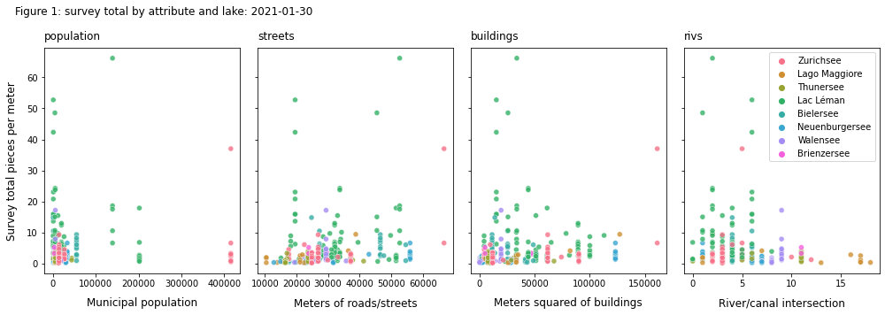

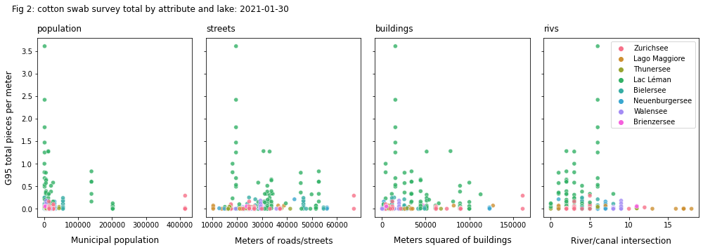

#### Geographic scope of surveys

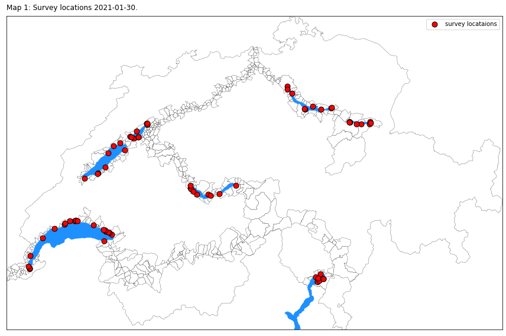

### Survey results

(table 1)

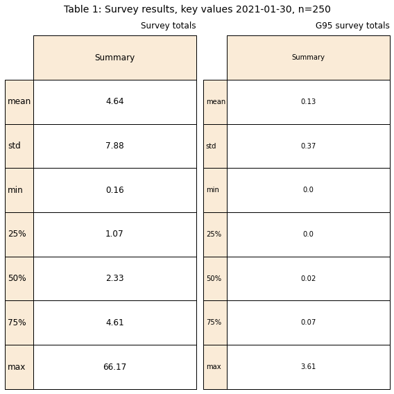

### Regional summary

(table 2).

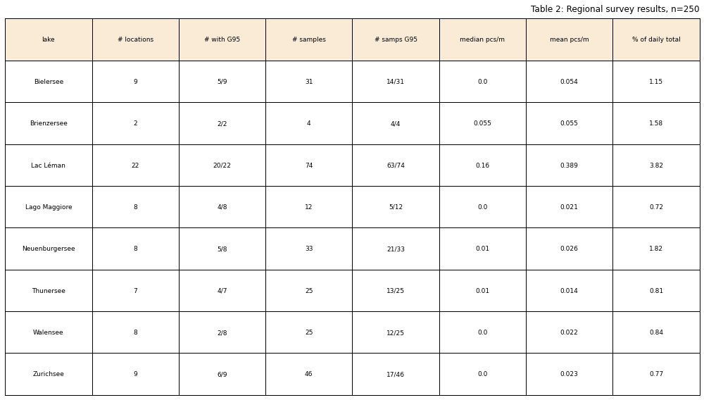

### Distribution of survey results

(fig 3).

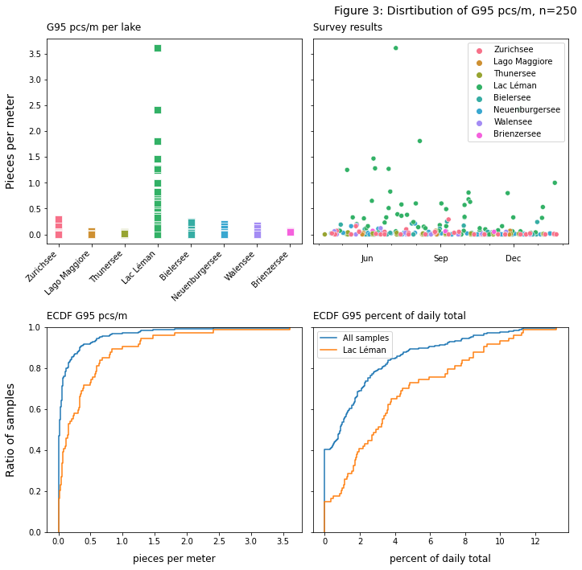

### Definition of significant values

Significant values are those survey values that are equal to or exceed the 90th percentile of all survey results for the defined code.

(table 3, fig 4).

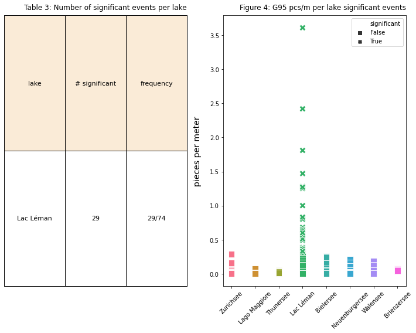

The chance of finding AT LEAST one G95 for every 10 meters of survey nationally is: ~22.8

The chance of finding AT LEAST one G95 for every 10 meters of survey on Lac Léman is: ~58.1%

### Geographic scope

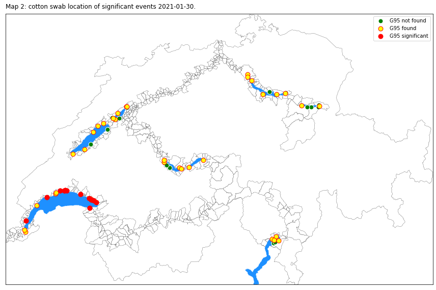

### Lac Léman results and conclusions

table 4, figure 5, table 5

[figure not shown]

[figure not shown]

### Use and distribution

(map 3).

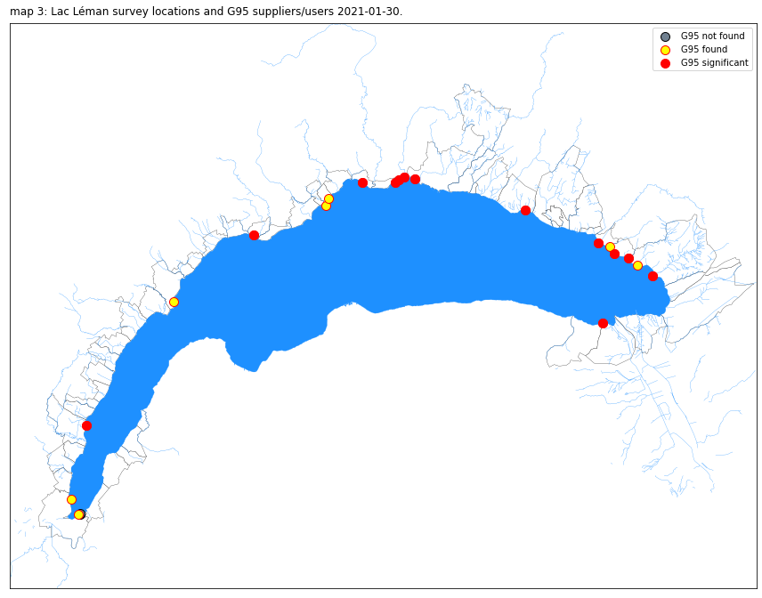

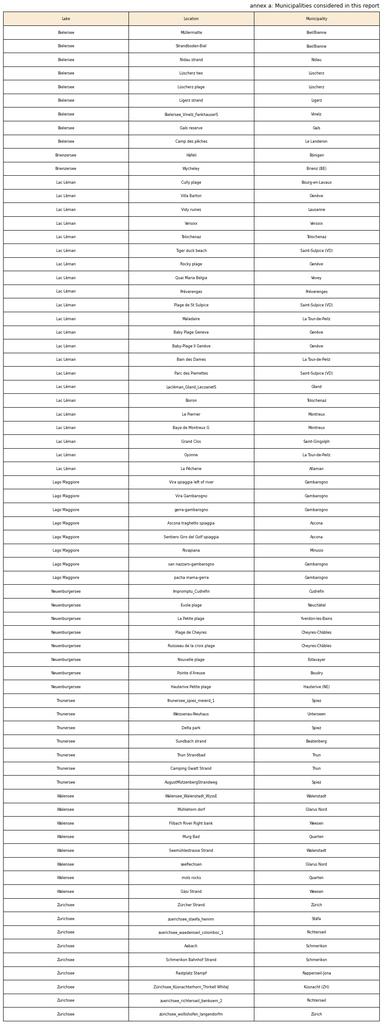

#### Hopefully that just worked for you

if not contact analyst@hammerdirt.ch